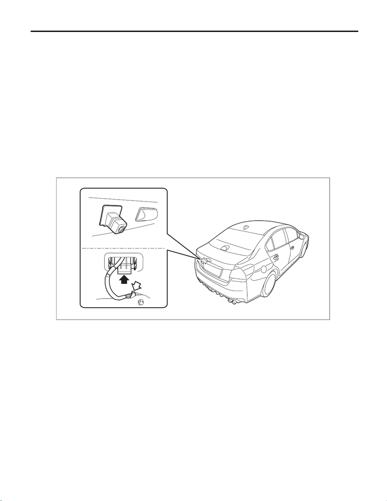

ET-21

Rearview Camera System

ENTERTAINMENT

15.Rearview Camera System

A: WIRING DIAGRAM

Refer to “Rearview Camera System” in the wiring diagram. <Ref. to WI-350, WIRING DIAGRAM, Rearview

Camera System.>

B: REMOVAL

1) Disconnect the ground cable from battery. <Ref. to NT-5, BATTERY, NOTE, Note.>

NOTE:

For models other than STI model, disconnect the ground terminal from battery sensor.

2) Remove the trim panel - trunk lid. <Ref. to EI-95, REMOVAL, Trunk Room Trim.>

3) Remove the garnish - trunk. <Ref. to EI-51, REMOVAL, Trunk Lid Garnish.>

4) Remove the rearview camera assembly.

CAUTION:

Do not drop or apply any impact to the rearview camera because it is a precision equipment.

(1) Disconnect the connector.

(2) Release the claw and hook, and then remove the rearview camera assembly.

C: INSTALLATION

1) Install the rearview camera assembly.

2) Install the garnish - trunk.

Tightening torque:

4.5 N·m (0.5 kgf-m, 3.3 ft-lb)

3) Install the trim panel - trunk lid.

4) Connect the battery ground terminal. <Ref. to NT-5, BATTERY, NOTE, Note.>

NOTE:

For models other than STI model, connect the ground terminal to battery sensor.

5) Confirm the marker position. <Ref. to ET-22, INSPECTION, Rearview Camera System.>

ET-00912

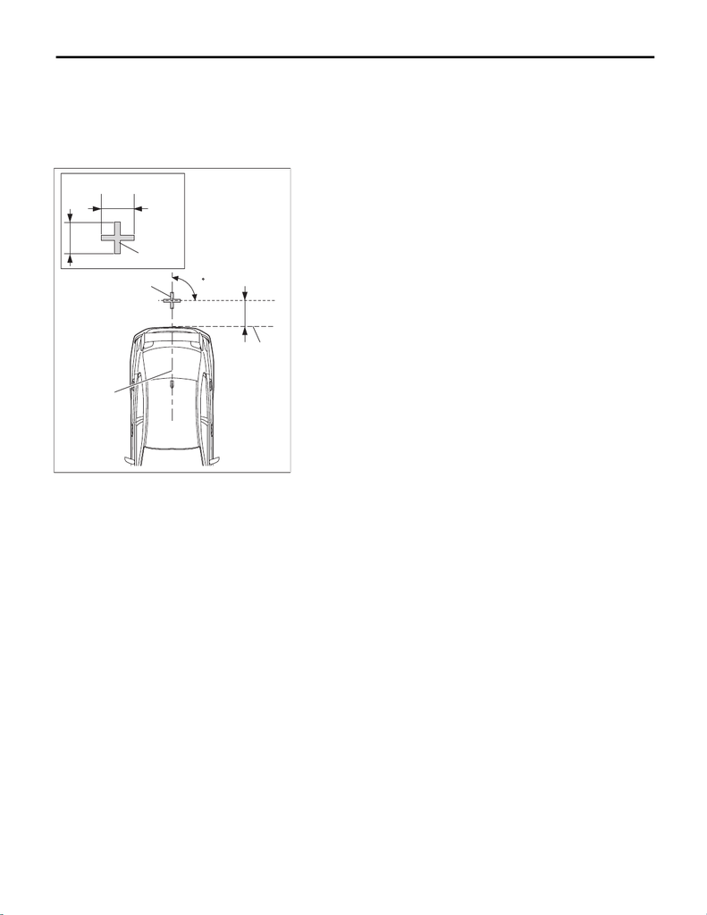

ET-22

Rearview Camera System

ENTERTAINMENT

D: INSPECTION

1) Park the vehicle at the level place where there are enough area at the rear of the vehicle.

2) Attach the tape as the target point for standard at the floor rearward of the vehicle as shown in the figure

below.

NOTE:

Standard tape width is about 30 — 50 mm (1.18 — 1.97 in) and brilliant color shall be used.

3) Confirm the following before checking the corresponding items.

• When the display is blank:

Rearview camera image is not displayed. (The multi-function display screen is displayed normally.)

– Check the condition of back sensor and rearview camera connection. <Ref. to IDI-10, DIAGNOSTIC

MODE, OPERATION, Multi-function Display (MFD) System.>

• When the marker position is not aligned:

E: ADJUSTMENT

1. MARKER ADJUSTMENT MODE

For marker adjustment, refer to “INSTRUMENTATION/DRIVER INFO”. <Ref. to IDI-10, DIAGNOSTIC

MODE, OPERATION, Multi-function Display (MFD) System.>

(A) Vehicle body center line

(B) Rear edge of bumper

(C) Target point

ET-00913

500 mm (19.69 in)

(B)

(C)

250 mm

(9.84 in)

250 mm

(9.84 in)

(C)

(A)